# index

Sheng Cao & Xiaolin Zheng

2/25/2022

[Data Source:CGSS2015](http://cgss.ruc.edu.cn/English/Home.htm)

```r
library(tidyverse)
library(naniar)
library(haven)
library(ggthemes)
```

```r
raw_data <- read_dta("cgss2015_14.dta")
```

## Part I. Data, Variable and Method

Among the many factors that affect the quality of life of the elderly, health has always played an important role. Traditionally, health mainly refers to the soundness of physiological functions, whereas the modern interpretation of health has a richer connotation. In 1946，the World Health Organization (WHO) defined health as “a state of complete physical, mental, and social well-being”. As the population aging problem has become one of the priorities of the Chinese government since it has huge financial burden, paying attention to the health of the aging population can help release the burden to some extent. Therefore, only by exploring health status from multiple perspectives can we better understand and improve the health condition of the elderly.

We use China General Social Survey (CGSS) 2015 to find demographic characteristics and variables associated with differences in health levels of the elderly.

For physical health, respondents were asked, “In the past four weeks, how often did health problems affect your work or other daily activities?” The responses were “always”, “often”, “sometimes”, “rarely” and “never”, and were assigned a value of “1 to 5” respectively.

We use descriptive statistics and reflect what we have in graphs.

```r
# load in the data
data <- raw_data %>%
  select(a2, a15, a16, a17, a681, a682, a69, a301,a7a)
```

```r
# rename the variable
data <- data %>%
  rename(
    "sex" = a2,
    "self_health" = a15,
    "phy_health" = a16,
    "mental_health" = a17,
    "n_son" = a681,
    "n_daughter" = a682,
    "marr_status" = a69,
    "yr_birth" = a301,
    "educ" =a7a
  )
```

```r
# generate new variables
data <- data %>%
  mutate(
    age = 2015 - yr_birth,
    n_kids = n_son + n_daughter,
    marr_status = case_when(
      marr_status == 1 ~ "0",
      marr_status == 5 ~ "0",
      marr_status == 6 ~ "0",
      marr_status == 7 ~ "0",
      TRUE ~ "1"
    ),
    sex = if_else(
      sex == 1, "Male", "Female"
    )
  )
```

```r
data <- data %>%
# replace certain values with NA.
   replace_with_na_at(c("self_health", "phy_health", "mental_health"), condition = ~.x == -8) %>%
  replace_with_na_at(c("n_kids"), condition = ~.x == -16) %>%
  replace_with_na_at(c("educ"), condition = ~.x == 14)%>%
  replace_with_na_at(c("educ"), condition = ~.x == -8)
```

```r
# filter the observations of interest
data <- data %>%
  filter(
    age >= 60
  )
```

## Part II. Data Visualization

### A. Difference of Health Status between Sex for people over 60

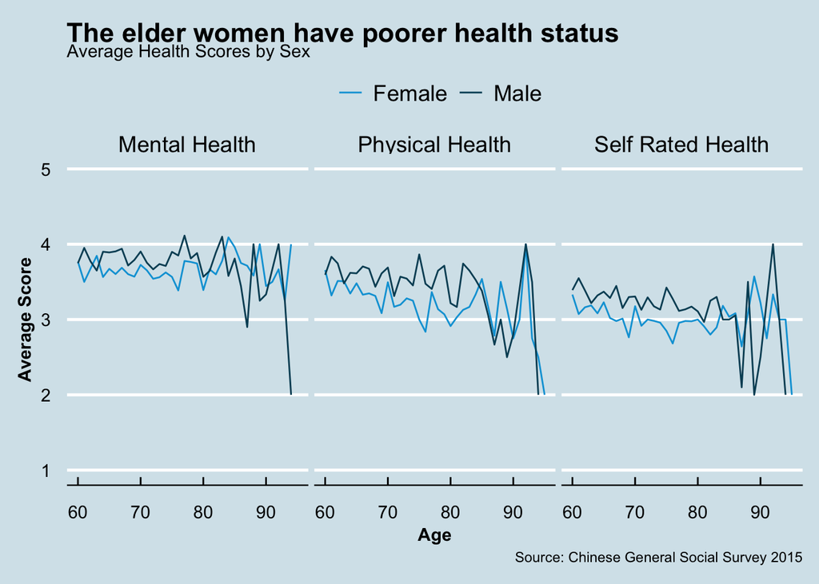

```r
# Figure 01

  # Data manipulation
subdata1 <- data %>%
  group_by(age, sex) %>%
  summarize(
   mean_self = mean(self_health, na.rm = TRUE),
   mean_phy = mean(phy_health, na.rm = TRUE),
   mean_mental = mean(mental_health, na.rm = TRUE)
  )

  # create a panel label name
lab_names1 <- c(
  `mean_mental` = "Mental Health",
  `mean_phy` = "Physical Health",
  `mean_self` = "Self Rated Health"
)

  # Draw the graph
F1 <- subdata1 %>%
  pivot_longer(cols = c(mean_self, mean_phy, mean_mental), names_to = "health", values_to = "average") %>%
  ggplot(mapping = aes(x = age, y = average, colour = sex)) +
  geom_line() +
  facet_wrap(~health, labeller = as_labeller(lab_names1)) +
  scale_y_continuous(limits = c(1, 5))

  # Add labels and themes
F1 +
  labs(
    title = "The elder women have poorer health status",
    subtitle = "Average Health Scores by Sex",
    caption = "Source: Chinese General Social Survey 2015",
    x = "Age",
    y = "Average Score"
  ) +
  theme_economist() +
  scale_color_economist(name = NULL) +
  theme(
    axis.title.x = element_text(margin = margin(5,0,0,0),
                                face = "bold"),
    axis.title.y = element_text(margin = margin(0,5,0,0),
                                face = "bold")
  )
```

### B. Health Status by Marriage Status

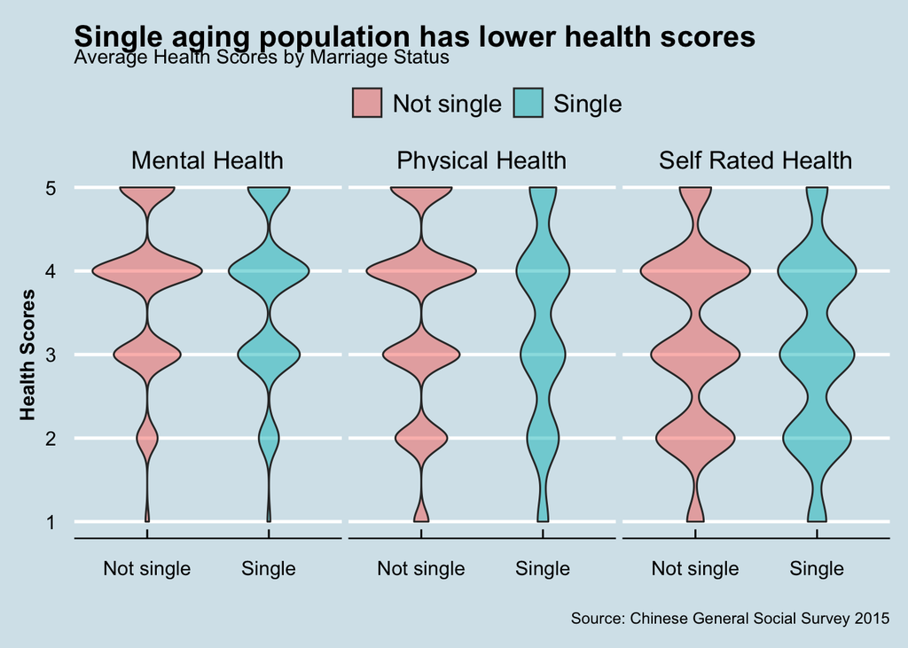

```r
# Figure 02

  #Data manipulation
subdata2 <- data %>%
  select(marr_status, self_health, phy_health, mental_health) %>%
  group_by(marr_status) %>%
  mutate(
    marr_status = recode(marr_status,
      `0` = "Single",
      `1` = "Not single"
    )
  )

  # create a panel label name
lab_names2 <- c(
  `mental_health` = "Mental Health",
  `phy_health` = "Physical Health",
  `self_health` = "Self Rated Health"
)

  # Draw the graph
F2 <- subdata2 %>%
  pivot_longer(cols = c(self_health,phy_health,mental_health),names_to = "health", values_to = "healthscores") %>%
  ggplot(mapping = aes(x = marr_status, y = healthscores, fill = marr_status)) +
  geom_violin(alpha = 0.5,adjust= 1,scale = "area") +
  facet_wrap(~health, labeller = as_labeller(lab_names2))

  # Add lables and themes
F2 +
  labs(
    title = "Single aging population has lower health scores",
    subtitle = "Average Health Scores by Marriage Status",
    caption = "Source: Chinese General Social Survey 2015",
    x = "",
    y = "Health Scores",
    fill = ""
  ) +
  theme_economist() +
  scale_color_economist(name = NULL) +
  theme(
    axis.title.x = element_text(margin = margin(5,0,0,0),
                                face = "bold"),
    axis.title.y = element_text(margin = margin(0,5,0,0),
                                face = "bold")
  )
```

We characterize those who have no partners who live with them as single and those who have the partner who live together as not single. We can conclude from the graph that those who have the partners are more likely to be healthier since more people among the Not single elderly have higher scores (4 and 5) in mental, physical and self-rated health. The difference among lower scores (3, 2 and 1) is not significant to see. So our pension policy should focus more on single aging population. Policymakers should implement series of laws to provide them with mental, physical health support.

### C. Health Status between the Elderly who Have Kids and No Kids

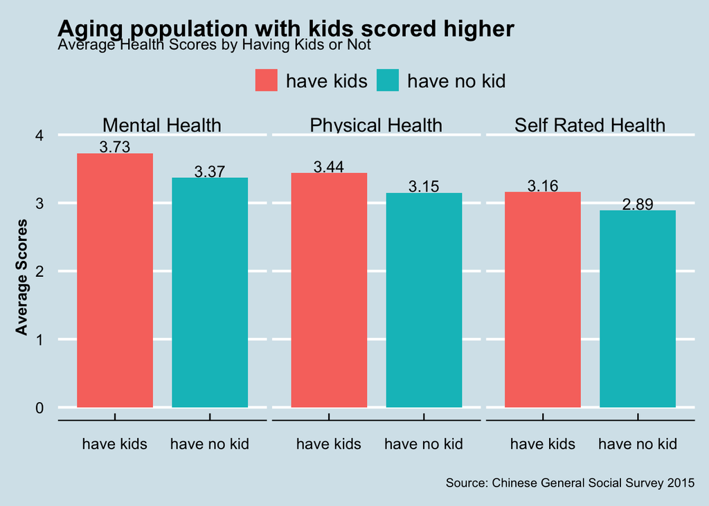

```r
# figure 03

  # Data manipulation
subdata3 <- data %>%
  mutate(
    no_kid = if_else(n_kids > 0, "have kids", "have no kid")
  ) %>%
  select(no_kid, self_health, phy_health, mental_health) %>%
   group_by(no_kid) %>%
  summarize(
    avrg_self = round(mean(self_health, na.rm = TRUE), digits = 2),
    avrg_phy = round(mean(phy_health, na.rm = TRUE),digits = 2),
    avrg_mental = round(mean(mental_health, na.rm = TRUE),digits = 2),
  ) %>%
  filter(!is.na(no_kid)) %>%
  pivot_longer(
    cols = c("avrg_self", "avrg_phy", "avrg_mental"),
    names_to = "health_type",
    values_to = "avrg_scores"
    )

  # Create a panel label name
lab_names3 <- c(
  `avrg_mental` = "Mental Health",
  `avrg_phy` = "Physical Health",
  `avrg_self` = "Self Rated Health"
)

  # Draw the graph
F3 <- subdata3 %>%
  ggplot() +
  geom_col(
    aes(
      no_kid,
      avrg_scores,
      group = no_kid,
      position = no_kid,
      fill = no_kid,
    ),
    width = 0.8,
  ) +
  scale_fill_discrete(name = "") +
  facet_wrap(~health_type, labeller = as_labeller(lab_names3)) +
  geom_text(
    aes(x= no_kid, y=avrg_scores, label=avrg_scores),
    size=4,
    nudge_y = 0.1,
    colour = "black",
    face = "bold"
    )

  # Add labels and themes
F3 +
  labs(
    title = "Aging population with kids scored higher",
    subtitle = "Average Health Scores by Having Kids or Not",
    caption = "Source: Chinese General Social Survey 2015",
    x = "",
    y = "Average Scores"
  ) +
  theme_economist()+
  scale_color_economist(name = NULL) +
  theme(
    axis.title.x = element_text(margin = margin(5,0,0,0),
                                face = "bold"),
    axis.title.y = element_text(margin = margin(0,5,0,0),
                                face = "bold")
  )
```

This figure shows average health scores of the elderly by having kids or not. The elder who have kids have higher scores in all three dimensions. One explanation is that kids can take care of the elderly，either by providing financial or emotional support. This implies that we should pay more attention to the elderly who do not have kids.

### D. The Relationship between Education Years and Health Status

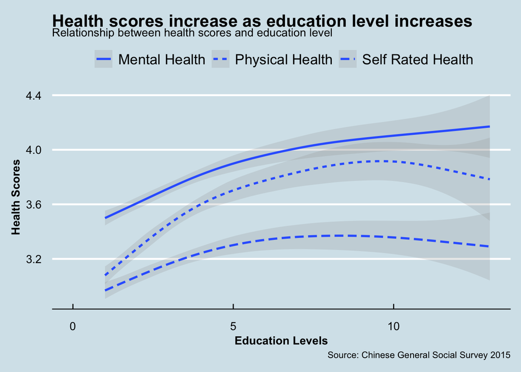

```r
# Figure 4

  # Data manipulation
subdata4 <- data %>%
  pivot_longer(cols = c(self_health, mental_health, phy_health),
               names_to = "health",
               values_to = "health_score")

  # Draw the graph
F4 <- subdata4 %>%
  ggplot() +
  geom_smooth(mapping = aes(x = educ , y = health_score, linetype = health), alpha = 0.2) +
  scale_x_continuous(limits = c(0, NA), breaks = seq(0, 20, by=5)) +
  scale_linetype_discrete(labels = c("Mental Health", "Physical Health", "Self Rated Health"))

  # Add labels and themes
F4 +
  labs(
    title = "Health scores increase as education level increases",
    subtitle = "Relationship between health scores and education level",
    caption = "Source: Chinese General Social Survey 2015",
    x = "Education Levels",
    y = "Health Scores",
    linetype = ""
       ) +
  theme_economist() +
  scale_color_economist(name = NULL) +
  theme(
    axis.title.x = element_text(margin = margin(5,0,0,0),
                                face = "bold"),
    axis.title.y = element_text(margin = margin(0,5,0,0),
                                face = "bold")
  )
```

As we can see, three health scores all improve as years of education increase. This improvement is more pronounced in mental and physical health. People who have higher education levels may have higher health awareness. They may go to medical visits timely and pay more attention to nutrition and physical exercise. Also, higher level of education among the elder indicate that they have a relatively better working environment prior to their retirement and therefore have a higher quality of life. From the policy perspective, this reminds to focus more on those with lower education level.

## Part III. Conclusion

In summary, we have found that the health of aging population is related to their sex, marriage status, having kids or not and education levels in China. When policymakers implement policies regarding the aging population, they should always consider about the different group characteristics among the aging population. For example, local government can cooperate with the local community to provide psychological counseling services to the elderly who have no kids. Also, local government should also offer a better working and social environment for women laborers so that they could be much healthier when they get older.

## Part IV. Stretch Exercise 1

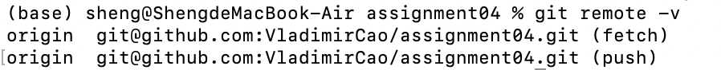

ShengCao

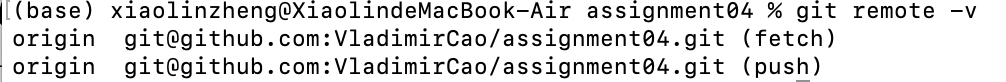

XiaolinZheng